# European integration in the last 20 years: macro vs micro evidence

#### Content

The following workbook is split into the following chapters and sections:

##### Motivation

1. Research Framework
   - Presents the research question and estimation approach
   - Details the different data sources used
2. Motivating macro figures
   - Downloads macro data (inflation, unemployment, long-term interest rates) from Eurostat
   - Displays motivating figures about changes in cross-country heterogeneity over time

##### Solution

3. Data collection
   - Download input-output tables from OECD
4. Data preparation
   - Combines, aggregates and reshapes IO tables to produce the dataset used in the analysis
   - As this section takes relatively long to run, the Notebook automatically stops if *full_dataset.csv* already exists in *results* folder (throws KeyboardInterruptError)
5. Data exploration
   - Gives summary statistics and figures about IO dataset
6. Data analysis
   - Runs regressions to estimate the impact of joining the EU on trade flows within vs outside the EU

##### Findings

7. Conclusion and outlook
   - Draws main conclusions from analysis
   - Highlights shortcomings and indicates paths for future projects

#### Important notes for usage

- When the file full_dataset.csv is already available and stored in a folder called "results", sections 3 and 4 should not be run to reduce computation time. Note that the imports in the Preparation cells should always be run.
- To keep the Notebook clean and reader-friendly, repeatedly used or especially long functions (such as those producing the dash applications) are imported from modules. Each section first imports the necessary modules, which also can be easily associated to them by name.

## I) Research framework

### Introduction and research question

The recently published Draghi report brought the problem of sluggish economic development in Europe again back into the center of political attention. The EU is currently falling behind the USA in a number of economic indicators, from overall growth to productivity enhancements to technological progress in key sectors for the future. This throws into question whether the hopes of economic progress associated with the foundation and expansion of the EU as a political and economic union have been justified. At the same time, we do not know, of course, in what state Europe would be without it.

As an important objective of the EU is to strengthen economic ties between members and reduce heterogeneity between them, assessing the economic impact of European integration often takes the form of testing for convergence in macroeconomic indicators. For example, if European integration had worked, we would expect a more similar movement of economic activity and prices in the different member states now than in the years before they were part of the EU. However, using macroeconomic time series for this is problematic, as co-movement across countries is strongly influenced by global events like the pandemic, which have nothing to do with European integration.

In this Notebook, I propose a different way of studying economic integration in Europe. Instead of macroeconomic indicators, I use sector-level data on sales and purchases in different European industries. As a metric for integration, I calculate the ratio of sales to (or purchases from) other European member states relative to sales to (purchases from) the rest of the world. In simple fixed-effects regressions, I estimate the effect of having joined or being in the EU or Eurozone for different sectors and discover important sectoral differences: some sectors seemingly profit a lot from EU membership (on average associated with +6% in share of sales to the EU), while others do not.

Shedding light on the sector-specific membership effect is also important for policymakers, as it can help to identify aspects of integration that have or have not worked well. For example, my analysis shows that within-EU sales in the agricultural sector have indeed strongly benefited from European integration, while the cultural sector has not profited at all, potentially due to a lack of efforts to strengthen cultural links. The latter is also a problem for labor mobility (as people tend to migrate less to culturally different places), which in turn is crucial for many macroeconomic developments.

### Data used

I use data from multiple sources:

- Country-level time series for selected macroeconomic indicators (inflation, unemployment, and long-term interest rates) all stem from Eurostat and are loaded into the project using the `eurostat` package (which accesses the Eurostat API)
- Country-industry-level data about sales and purchases of different industries come from the OECD's [inter-country input-output tables](https://www.oecd.org/en/data/datasets/inter-country-input-output-tables.html) (IO tables in the following). Section 3 downloads the respective csv-files from the OECD website and stores them in the *data* folder.
- Information about countries' membership in EU and Eurozone as well as their year of entry is available on Wikipedia (see [this page](https://en.wikipedia.org/wiki/Member_state_of_the_European_Union) for EU). The functions in the `get_eu_euro_members` module scrape the information from Wikipedia and turn the online tables into locally stored dataframes.

### Preparation

Install necessary packages from *requirements.txt*, save list of available ports (for running multiple dash applications at the same time), and import module for displaying figures. If you do not use pip for managing packages, please change the first line in the following cell.

```python
#!pip install -r "requirements.txt"
    # to be changed if not using pip

import os
import plotly.express as px
import plotly.io as pio
pio.templates.default = "seaborn"

# prepare ports to be used by the different dash applications (so that they can run simultaneously)
free_ports = [8050,8051,8124]
    # these should usually be free

# import module for Notebook functionalities (displaying figures)
import assets
```

```python
# Create folders if they not exist
folders = ['../temp/','../results/','../data/']
for folder in folders:
    if not os.path.exists(folder):
        os.makedirs(folder)
```

## II) Motivating macro figures

This section illustrates the problem with looking at country-level macroeconomic indicators to study European economic integration. To this end, I first import the data on inflation, unemployment rates, and long-term interest rates (here interest rates on ten year government bonds) for the all 27 current EU members from Eurostat, using the package `eurostat` to access the respective API.

```python
from macro_intro import *
```

```python
macro_df = get_macro_data()
    # downloads data from Eurostat and combines it into single dataframe
macro_df.head(3)
```

|  | Date | Inflation | Unemployment | Long-Term Interest Rate | Country |
| --- | --- | --- | --- | --- | --- |
| 0 | 1997-01-01 | 1.2 | 5.5 | 5.84 | Austria |
| 1 | 1997-02-01 | 1.4 | 5.8 | 5.58 | Austria |
| 2 | 1997-03-01 | 1.2 | 5.8 | 5.71 | Austria |

As half of the now member countries have joined after 2000 (with the Eastern European enlargement in 2004 bringing in 10 new member states), we may expect a convergence in economic conditions for European countries. As a very crude metric, the following figure plots the yearly cross-country variance for the three indicators of interest. Economic convergence would imply less heterogeneity in recent years than decades ago, in which case we should expect to see falling time trends.

```python
# Use variance as crude dispersion measure and display time series
dispersion_graph(macro_df)
```

[interactive chart not shown]

We see that we do not see anything really: While the heterogeneity in unemployment has decreased over time, we see large spikes in economic dispersions in times of global economic unrest (such as the financial crisis in 2008 or the Russian war in Ukraine since 2022). Because of these shocks, one cannot really identify a clear trend.

For a more detailed picture, I now sort all member countries into three groups, depending on when they joined the EU. Although we thereby use any within-group heterogeneity, it enables a simple eyeball test: The ten countries having joined in 2004 should have converged to the existing members only after 2004, while the group of "latecomers" (Bulgaria, Romania, and Croatia) should have converged only after 2007/2013. To look at the three different indicators, select them from the dropdown menu at the top of the figure.

```python
from get_eu_euro_members import *
df_eu = get_wiki_table('EU')
    # get year of EU join to sort countries into groups

early_members = df_eu.loc[df_eu['Year']<1997,'Country']
eastern_members = df_eu.loc[df_eu['Year']==2004,'Country']
late_members = df_eu.loc[df_eu['Year']>2005,'Country']

macro_df['Country Group'] = 'Early members'
macro_df.loc[macro_df['Country'].isin(eastern_members),'Country Group'] = 'Eastern members'
macro_df.loc[macro_df['Country'].isin(late_members),'Country Group'] = 'Late members'

macro_df.to_csv('../temp/macro-data.csv')
    # to be used by dash application
```

```python
# Run the app
from macro_intro_dash import app_macro

app_macro.run_server(use_reloader=False,port=free_ports[0])
```

[interactive chart not shown]

While the figure for inflation looks more or less like expected, the unemployment graph shows that the convergence does not really relate to the year of entry, while interest rates do not show any systematic convergence trend at all. As before, global shocks distort the picture, so that one cannot draw any conclusions from here. For this reason, we will now turn our attention to industry-level data.

## III) Data Collection

##### Inter-Country Input-Output Tables from OECD

The code in the next cell automatically downloads the relevant files from the [OECD website](https://www.oecd.org/en/data/datasets/inter-country-input-output-tables.html), unless they are already stored in the *data* folder.

```python
from get_icio import *

# get IO-tables from OECD for years 1995-2020 (one per year)
download()
```

```
Data for 1995-2000 already exists (file 1/5)
Data for 2001-2005 already exists (file 2/5)
Data for 2006-2010 already exists (file 3/5)
Data for 2011-2015 already exists (file 4/5)
Data for 2016-2020 already exists (file 5/5)
```

The structure of the downloaded files is the following (see also the OECD's documentation file in the *assets* folder.

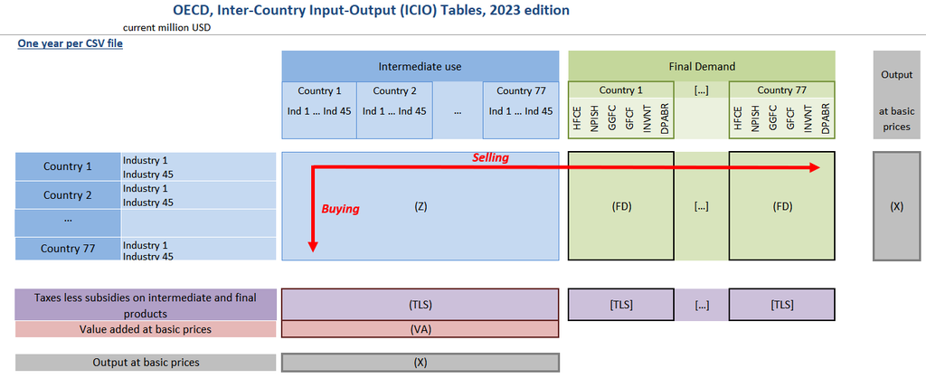

```python
assets.img_colab('icio_structure.png')
```

Reading example: To look for the amount of good bought by country-industry pair A-1 from country-industry pair B-2, we have to look at the cell in column "A-1" and row "B-2".

##### Membership data (Wikipedia)

To analyse the aggregate behavior of EU/Euro members and estimate the impact of joining an economic area on import/export patterns, I scrape membership data from Wikipedia and build a dataframe that can be merged to the reshaped IO-table.

```python
from get_eu_euro_members import *

df_membership = build_membership_df()

eu_members = pd.unique(df_membership['Country Code'])
    # all countries that are now in the EU
euro_members = pd.unique(df_membership[df_membership['Euro']=='Yes']['Country Code'])
```

```python
from get_eu_euro_members import *
eu_euro_members(df_membership).show()
```

[interactive chart not shown]

## IV) Data Preparation

Unfortunately, the shape of the OECD data pictured above is not very convenient for analyzing the data. Therefore, the separate files are not only combined but also reshaped to get a dataframe with the following structure:

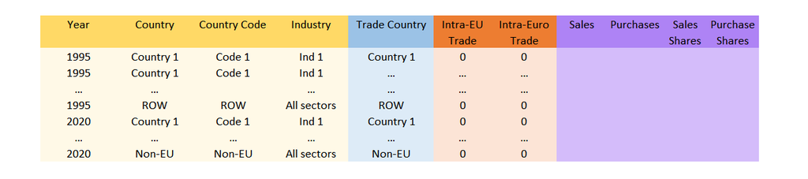

```python
assets.img_colab('df_structure.png')
```

There are multiple differences to note from the original dataset:

- The data from all years is combined
- As exports and imports are symmetric, the partnering sectors are no longer reported (i.e., trade is only reported on the country-industry-country level), reducing the data size without losing relevant information. Trade shares across trade partners are simply summed up over country, industry and year
- The target country is no longer specified in different variables but in a single column (making the dataframe longer)
- Non-EU countries are added up as "Rest of the world" to reduce the size of the data
- While the OECD data distinguishes 45 industries (NAICS subsectors, NAICS being the classification system), my dataset records 36 industries by aggregating NAICS subsectors to sectors (except for the quantitatively more relevant manufacturing subsectors beginning with the letter "C")
- I add an aggregate industry "All sectors" summing up the trade values for all sectors (getting industry code " * ")
- For aggregate statistics and the analysis later on, I add dummies variables indicating whether trade happens between two EU or Euro members

Note that an industry selling goods in its home country is not reported as Intra-EU/Euro trade. This is because we are ultimately interested in whether political integration led to more cross-border trade within Europe, so that we do not want to count an increase in home sales when looking at the development of "European" trade. Of course, for all trade happening between different countries, sales are exports and purchases are imports.

While it could be of interest to study Intra-EU trade for industry-pairs, only looking at how much an industry in a country sells to or buys from other countries is enough to estimate industry-specific integration effects. As the above list shows, reducing the data size was a relevant aspect when designing the dataset used. After all, we already have 26 years, 29 countries and 36 industries, leading to 787,176 observations. Keeping trade partners on the sectoral level would further multiply this number by a factor of 36.

Nevertheless, because of the still relatively large number of rows and the number of aggregation calculations that have to be done, the data preparation process takes some time (especially on older computers). To avoid too long waiting times, this section should therefore not be run if the resulting dataset already exists (*full_dataset.csv* in the *results* folder). The following cell ensures this by throwing an error and stopping the notebook execution in that case.

```python
if os.path.exists(f'../results/full_dataset.csv'):
        print('Dataset already exists, import from csv')
        raise KeyboardInterrupt
        # stops execution of whole cell if final dataset already created
```

```
Dataset already exists, import from csv
```

[output not shown]

To construct the dataset has outlined before, I first calculate the Sales column and then use the symmetry of sales and purchases to also calculate Purchases. For the sales data, I follow these steps (all combined in the next cell's function), which are implemented as functions in the `prepare_icio` module:

1. Turn csv file into dataframe (function `icio_to_dataframe`)
2. Reshape dataframe to long format (function `wide_to_long` using `pd.melt`)
3. Aggregate non-EU countries and industries except manufacturing (function `collapse_row` using `groupby`)
4. Generate indicator variables for within EU/Eurozone trade

```python
from prepare_icio import *

def create_dataset_exports(start,end):
    if os.path.exists(f'../temp/dataset_exports.csv'):
        print('Dataset already exists, import from csv')
        raise KeyboardInterrupt
        # stops execution of whole cell if csv already created

    else:
        df = collapse_row(wide_to_long(icio_to_dataframe(f'../data/{start}_SML.csv'),'Sales',start),eu_members)
        # executes the above preparation steps in the given order
        print(f'Dataset created beginning in year {start}')
        for y in range(start+1,end+1):
            df = pd.concat([df,collapse_row(wide_to_long(icio_to_dataframe(f'../data/{y}_SML.csv'),'Sales',y),eu_members)],ignore_index=True)
            print(f'Year {y} added to dataset')
        return df
```

```python
data_short_exports = create_dataset_exports(1995,2020)
    # downloads IO tables for each year, saves them as separate csv files (in data folder) and loads them together
```

To create the dataframe containing imports, I make use of the fact the exports and imports are symmetric for each country-sector pair in a given year. Therefore, I just have to switch home and trade partner country/sector.

```python
if os.path.exists('../temp/dataset_imports.csv'):
        print('Dataset already exists, import from csv')
        raise KeyboardInterrupt
        # stops execution of whole cell if csv already created

data_short_imports = data_short_exports.rename(columns={'Country Code':'Trade Country Code','Industry Code':'Trade Sector',
                     'Trade Country Code':'Country Code','Trade Sector':'Industry Code',
                     'Sales':'Purchases'})[['Country Code', 'Industry Code', 'Trade Country Code', 'Trade Sector', 'Year', 'Purchases']]
data_short_imports = data_short_imports.drop('Trade Sector',axis=1).groupby(['Country Code','Industry Code','Year','Trade Country Code']).sum()
    # the information about from which sector the imports stem is of no relevance for the later analysis
```

```python
# Now we can also shorten the export dataset
data_short_exports = data_short_exports.drop('Trade Sector',axis=1).groupby(['Country Code','Industry Code','Year','Trade Country Code']).sum()
```

Finally, I combine the export and import data in a single dataset and generate two new variables.

```python
if os.path.exists(f'../results/full_dataset.csv'):
        print('Dataset already exists, import from csv')
        raise KeyboardInterrupt
        # stops execution of whole cell if csv already created

# Combine both exports and imports
df = pd.merge(data_short_exports, data_short_imports,
         on=['Country Code', 'Industry Code', 'Trade Country Code', 'Year'],
         how='left').groupby(['Country Code','Year','Industry Code','Trade Country Code']).sum().reset_index()

df = df[df['Industry Code']!='T']
    # get rid of quantitatively irrelevant sector

df_add_total = df.drop(['Industry Code'],axis=1).groupby(['Country Code','Year','Trade Country Code']).sum()
df_add_total['Industry Code'] = '*'
df = pd.concat([df_add_total.reset_index(),df])

# Create variables for shares of sales/purchases
df['Sales Shares'] = df['Sales'] / df.groupby(['Country Code','Year','Industry Code'])['Sales'].transform('sum') * 100
df['Purchases Shares'] = df['Purchases'] / df.groupby(['Country Code','Year','Industry Code'])['Purchases'].transform('sum') * 100

# Create dummy variables for trade within EU/Eurozone
df = classify_trade(df,eu_members,'Intra-EU Trade')
df = classify_trade(df,eu_members,'Intra-Euro Trade')

# Change order of columns
df = df[['Year','Country Code','Industry Code','Trade Country Code','Intra-EU Trade','Intra-Euro Trade',
         'Sales','Purchases','Sales Shares','Purchases Shares']]
df.to_csv('../results/full_dataset.csv',index=False)
```

```python
# Control the generated dataset
pd.read_csv('../results/full_dataset.csv').head(5)
```

## V) Data Exploration

The below cell imports the previously generated dataset, so that the notebook can be run from here onwards without the previous sections (note that the preparation cell at the very top has to be run beforehand).

```python
from exploration import *

import pandas as pd

# Import the before constructed dataset (in case sections II and III were not run)
data = pd.read_csv('../results/full_dataset.csv')
```

To give the user a first impression of the available data, I produce an interactive map-chart displaying the shares of imports and exports for any European country (selectable by clicking on the map). To that end, I add labels to the dataset to and calculate import/export shares (more informative than just the raw trade numbers), ignoring within-country sales/purchases

```python
dataframe_map(data).to_csv('../temp/df_map.csv',index=False)
    # store data as csv so that it can be used by Dash module
```

```python
from exploration_dash_1 import app_map

# Run the app in the notebook
app_map.run_server(use_reloader=False, port=free_ports[2])
    # opening different ports allows running multiple Dash applications at the same time
```

[interactive chart not shown]

A good example of the type of development in which we are interested is the change in export patterns for the Polish industry producing machinery and equipment: Comparing the situation in 1995 and 2020, we see that the share of exports going to European countries has not only increased for well-established trade relations (such as sales to German industries), but also for previously underdeveloped trade relations to other European countries (both in the direct neighborhood and to countries like France or Italy). However, looking at the animated development over the years, we can see that this change actually started to happen even before Poland joined the EU in 2004. To separate changes caused by the European integration from long-term trends, we therefore need a more systematic analysis.

Next, I generate summary statistics for exports (imports available by changing the parameter in below function) in the last year of the dataset. Unsurprisingly, the average size of the different sectors is very different. As we are interested in relative changes over time, this is not very important to our analysis. What is important, however, is the number of countries trading in a certain sector. After all, we want to exploit the difference in trade patterns between these countries that joined the EU or Eurozone in a given period and those that did not. Looking at the different quartiles, we see that for many sectors, a quarter of all countries export few, if any, goods.

To assess the degree of heterogeneity in cross-border trade, I also report the coefficient of variation. The higher it is, the higher the variance in sales for a given sector across countries. As our analysis seeks to exploit trade heterogeneity, higher variance in a sector is principally better for estimating significant effects.

```python
summary_table(data,'Sales',2020)
```

| Industry | Mean_Sales | Q25_Sales | Median_Sales | Q75_Sales | Variance_Coefficient_Sales |
| --- | --- | --- | --- | --- | --- |
| All sectors | 4394 | 110 | 365 | 960 | 4.3 |
| Wholesale and retail trade; repair of motor vehicles | 472 | 12 | 42 | 137 | 4.2 |
| Real estate activities | 352 | 7 | 31 | 77 | 4.1 |
| Financial and insurance activities | 301 | 6 | 17 | 85 | 4.2 |
| Transport, warehousing, postal activities | 245 | 9 | 25 | 80 | 4.1 |
| Food products, beverages and tobacco | 243 | 5 | 20 | 72 | 4.4 |
| Agriculture, fishing, hunting, forestry | 229 | 4 | 12 | 35 | 4.9 |
| Professional, scientific and technical activities | 216 | 5 | 22 | 83 | 3.9 |
| Publishing, IT, Telecommuncations | 199 | 7 | 23 | 71 | 4.0 |
| Mining | 150 | 1 | 2 | 6 | 5.2 |
| Administrative and support services | 144 | 3 | 11 | 43 | 3.8 |
| Basic metals | 134 | 2 | 6 | 16 | 4.8 |
| Human health and social work activities | 133 | 1 | 7 | 18 | 4.7 |
| Electricity, gas, steam and air conditioning supply | 125 | 3 | 12 | 29 | 4.1 |
| Chemical and chemical products | 124 | 2 | 7 | 33 | 4.5 |
| Accommodation and food service activities | 111 | 2 | 7 | 22 | 4.3 |
| Computer, electronic and optical equipment | 104 | 1 | 4 | 11 | 4.9 |
| Textiles, textile products, leather and footwear | 97 | 1 | 2 | 10 | 5.0 |
| Motor vehicles, trailers and semi-trailers | 97 | 0 | 11 | 29 | 4.1 |
| Coke and refined petroleum products | 93 | 1 | 5 | 18 | 4.8 |
| Construction | 88 | 4 | 12 | 63 | 3.3 |
| Fabricated metal products | 72 | 2 | 6 | 20 | 4.1 |
| Other non-metallic mineral products | 68 | 1 | 4 | 9 | 4.7 |
| Rubber and plastics products | 60 | 2 | 5 | 12 | 4.4 |
| Electrical equipment | 59 | 1 | 3 | 12 | 4.5 |
| Machinery and equipment | 58 | 1 | 4 | 14 | 4.1 |
| Repair and installation of machinery and equipment | 57 | 1 | 5 | 19 | 4.1 |
| Education | 56 | 1 | 3 | 5 | 4.5 |
| Public administration and defence; compulsory social security | 52 | 1 | 2 | 11 | 4.5 |
| Paper products and printing | 52 | 1 | 3 | 16 | 4.4 |
| Pharmaceuticals, medicinal chemical and botanical products | 46 | 1 | 3 | 17 | 4.1 |
| Other service activities | 45 | 1 | 3 | 10 | 4.2 |
| Water supply; sewerage, waste management and remediation activities | 36 | 1 | 4 | 12 | 3.5 |
| Arts, entertainment and recreation | 27 | 1 | 3 | 7 | 3.7 |
| Wood and products of wood and cork | 25 | 1 | 4 | 9 | 4.3 |
| Other transport equipment | 24 | 0 | 1 | 5 | 4.1 |

```python
change_statistics = summary_table(data,'Sales',2020)/summary_table(data,'Sales',1995)
change_statistics[['Mean_Sales','Median_Sales','Variance_Coefficient_Sales']].round(1).sort_values('Variance_Coefficient_Sales',ascending=False)
```

| Industry | Mean_Sales | Median_Sales | Variance_Coefficient_Sales |
| --- | --- | --- | --- |
| Construction | 3.4 | 2.4 | 1.4 |
| Other non-metallic mineral products | 3.4 | 2.0 | 1.3 |
| Wood and products of wood and cork | 2.5 | 2.0 | 1.3 |
| Textiles, textile products, leather and footwear | 2.8 | 0.7 | 1.3 |
| Professional, scientific and technical activities | 3.7 | 4.4 | 1.2 |
| All sectors | 3.0 | 2.1 | 1.2 |
| Agriculture, fishing, hunting, forestry | 3.7 | 1.3 | 1.2 |
| Administrative and support services | 3.5 | 3.7 | 1.2 |
| Food products, beverages and tobacco | 2.8 | 1.8 | 1.2 |
| Basic metals | 3.4 | 2.0 | 1.2 |
| Electrical equipment | 3.0 | 3.0 | 1.2 |
| Chemical and chemical products | 2.8 | 3.5 | 1.2 |
| Paper products and printing | 1.7 | 1.0 | 1.2 |
| Public administration and defence; compulsory social security | 5.8 | 2.0 | 1.2 |
| Water supply; sewerage, waste management and remediation activities | 3.3 | 4.0 | 1.2 |
| Rubber and plastics products | 2.6 | 5.0 | 1.2 |
| Fabricated metal products | 2.5 | 3.0 | 1.2 |
| Machinery and equipment | 2.8 | 4.0 | 1.2 |
| Accommodation and food service activities | 2.4 | 3.5 | 1.1 |
| Computer, electronic and optical equipment | 3.4 | 4.0 | 1.1 |
| Real estate activities | 2.9 | 3.4 | 1.1 |
| Publishing, IT, Telecommuncations | 3.4 | 3.8 | 1.1 |
| Other service activities | 1.9 | 1.5 | 1.1 |
| Motor vehicles, trailers and semi-trailers | 2.5 | 11.0 | 1.1 |
| Electricity, gas, steam and air conditioning supply | 3.2 | 2.4 | 1.1 |
| Coke and refined petroleum products | 3.4 | 2.5 | 1.1 |
| Mining | 4.7 | 2.0 | 1.1 |
| Financial and insurance activities | 3.3 | 2.4 | 1.1 |
| Transport, warehousing, postal activities | 3.0 | 3.1 | 1.1 |
| Repair and installation of machinery and equipment | 2.5 | 2.5 | 1.1 |
| Wholesale and retail trade; repair of motor vehicles | 2.7 | 2.5 | 1.1 |
| Other transport equipment | 3.0 | inf | 1.1 |
| Education | 2.3 | 3.0 | 1.0 |
| Human health and social work activities | 3.3 | 2.3 | 1.0 |
| Pharmaceuticals, medicinal chemical and botanical products | 4.2 | 3.0 | 1.0 |
| Arts, entertainment and recreation | 2.1 | 3.0 | 0.9 |

When estimating the effect of European integration on trade, we have to make a choice: Do we want to measure absolute changes in trade patterns ("European integration increased exports in industry A on average by x€ per year") or relative changes ("European integration increased exports to other European countries relative to the rest of the world in industry A on average by x% per year")? I opt for the second measure, as the relative impact of a country on the final estimates otherwise depends on its economic size, although the new members of interest are smaller than the existing members in 1995.

To prepare the quantitative analysis, I make some additional changes to the dataset:

- Add a new variable for ratio of exports to countries within/outside the EU (the relative measure of interest)
- Drop outliers for these trade ratios (caused by very small trade volumes in some national sectors)

```python
df_analysis = (data.drop(['Trade Country Code','Intra-Euro Trade','Sales Shares','Purchases Shares'],axis=1).
    groupby(['Country Code','Industry Code','Intra-EU Trade','Year']).sum().reset_index().
    pivot(columns='Intra-EU Trade',index=['Country Code','Industry Code','Year']).reset_index())
df_analysis.columns = ['Country Code', 'Industry Code', 'Year', 'Non-EU Sales', 'EU Sales', 'Non-EU Purchases' ,'EU Purchases']

# Create new variables:
df_analysis['Exports in/out EU'] = round(df_analysis['EU Sales'] / df_analysis['Non-EU Sales'],2) * 100
df_analysis['Imports in/out EU'] = round(df_analysis['EU Purchases'] / df_analysis['Non-EU Purchases'],2) * 100

# Add labels:
df_analysis = pd.merge(df_analysis,pd.read_excel('../assets/codes.xlsx',sheet_name='Industries'),on='Industry Code')
df_analysis = pd.merge(df_analysis,pd.read_excel('../assets/codes.xlsx',sheet_name='Countries'),on='Country Code')

df_analysis.to_csv('../temp/df_analysis.csv',index=False)
```

From the following graph, we see that there are a lot of outliers for the trade ratio variables, stemming from extremely low values in the denominator (close to zero trade with countries outside the EU). Before the analysis, we have to get rid of these to not distort our estimates by extreme changes in these ratios. We also have to drop those observations for which the trade ratio is zero, as we cannot calculate growth rates for these.

```python
fig = px.histogram(df_analysis,x=['Exports in/out EU','Imports in/out EU'],nbins=100,barmode='group',
             title='<b>Distribution of trade ratios</b>')
fig.update_yaxes(title="Occurences")
fig.update_xaxes(title="Values")
fig.update_legends(title="", orientation="h", yanchor="top", y=0.8, xanchor="left", x=0.55)
```

[interactive chart not shown]

Now we can take a final look at these measures before we run regressions on the data. The following graph shows how the share of exports or imports to other EU countries has changed for different industries and countries, while also indicating during which period the country was a member of the EU. Taking Poland again as an example, one cannot identify any boost in total exports or imports to other EU countries after 2004, when Poland became a member state. This emphasizes the importance of accounting for differences at the sectoral level.

```python
from exploration_dash_2 import app_timeline

# Run the app inside the notebook
app_timeline.run_server(use_reloader=False, port=free_ports[1])
    # opening different ports allows running multiple Dash applications at the same time
```

[interactive chart not shown]

## VI) Data Analysis

```python
from analysis import *
from get_eu_euro_members import *

df_analysis = pd.read_csv('../temp/df_analysis.csv')
df_analysis = df_analysis[(df_analysis['Exports in/out EU'] < 15)&(df_analysis['Imports in/out EU'] < 15)
                            &(df_analysis['Exports in/out EU'] > 0)&(df_analysis['Imports in/out EU'] > 0)]
    # drop outliers for trade ratios

# Create dictionary with years of entry to EU for each country
eu_join = get_wiki_table('EU')
eu_join_year = dict(zip(eu_join['Country'], eu_join['Year']))
```

In the previous figure, I only provided "eyeball tests" for the effects of joining the EU in different sectors. Now I want to estimate the effects in my dataset using linear regressions. The workhouse model for estimating treatment effects on trade flows is the so-called Gravity model, which is build on the insight that the trade flow between two countries depends on their economic size and distance potential trade barriers such as tariffs, different currencies, different languages etc.

As this type of analysis is beyond the scope of this project, I estimate simpler regressions. Specifically, I want to estimate how the share of exports (imports) to (from) EU-members relative to that share to (from) the rest of the world changes in the years after joining the EU. For that, I apply the regression $$ RelativeExports_{cst} = \beta \cdot JoinDummy_{ct} + FE_c + FE_t$$ for country $c$, sector $s$, and year $t$.

The right hand side variables are the following:

- $JoinDummy_{ct} \rightarrow$ Indicate whether the country of interested has joined the EU. To try different specifications, I construct dummies for
  - having joined the EU in the last 5 years
  - having joined the EU in the last 10 years
  - having joined the EU at all
  - the period 3 years before and after joining the EU (in case anticaption of entry matters)
- $FE_c \rightarrow$ Country fixed effects capturing constant country characteristics such as location
- $FE_t \rightarrow$ Time fixed effects capturing events in a given year that affect all countries alike such as an international economic downturn

The coefficient of interest $\beta$ tells us by how many percentage points the ratio of exports (imports) to EU-members relative to Non-EU countries increased or decreased on average after joining the EU.

```python
# Create the JoinDummies:

df_analysis['Five_Years_After'] = 0
for c in eu_join_year.keys():
    df_analysis.loc[(df_analysis['Country']==c) & (df_analysis['Year'].isin(range(eu_join_year[c],eu_join_year[c]+5))),'Five_Years_After'] = 1

df_analysis['Ten_Years_After'] = 0
for c in eu_join_year.keys():
    df_analysis.loc[(df_analysis['Country']==c) & (df_analysis['Year'].isin(range(eu_join_year[c],eu_join_year[c]+10))),'Ten_Years_After'] = 1

df_analysis['EU_Member'] = 0
for c in eu_join_year.keys():
    df_analysis.loc[(df_analysis['Country']==c) & (df_analysis['Year'] >= eu_join_year[c]),'EU_Member'] = 1

df_analysis['Three_Years_Around'] = 0
for c in eu_join_year.keys():
    df_analysis.loc[(df_analysis['Country']==c) & (df_analysis['Year'].isin(range(eu_join_year[c]-3,eu_join_year[c]+3))),'Three_Years_Around'] = 1
```

For a regression to be able to estimate the effects of the JoinDummies variables, we must ensure that there is variation for this dummies in all samples for which we run the regression. The following table depicts the share of observations per Industry for which the $JoinDummy$ is 1.

```python
(df_analysis.groupby(['Industry'])[['Five_Years_After', 'Ten_Years_After', 'Three_Years_Around', 'EU_Member']].
         mean().sort_values(['EU_Member','Three_Years_Around'], ascending=False).round(2)*100)
```

| Industry | Five_Years_After | Ten_Years_After | Three_Years_Around | EU_Member |
| --- | --- | --- | --- | --- |
| Electrical equipment | 0.0 | 0.0 | 0.0 | 100.0 |
| Motor vehicles, trailers and semi-trailers | 0.0 | 0.0 | 0.0 | 100.0 |
| Repair and installation of machinery and equipment | 0.0 | 0.0 | 0.0 | 100.0 |
| Rubber and plastics products | 0.0 | 0.0 | 0.0 | 100.0 |
| Textiles, textile products, leather and footwear | 0.0 | 2.0 | 0.0 | 100.0 |
| Human health and social work activities | 0.0 | 14.0 | 0.0 | 97.0 |
| Wood and products of wood and cork | 2.0 | 4.0 | 3.0 | 95.0 |
| Other transport equipment | 0.0 | 6.0 | 0.0 | 94.0 |
| Public administration and defence; compulsory social security | 9.0 | 22.0 | 9.0 | 92.0 |
| Construction | 8.0 | 21.0 | 8.0 | 91.0 |
| Paper products and printing | 0.0 | 0.0 | 0.0 | 91.0 |
| Education | 10.0 | 21.0 | 11.0 | 88.0 |
| Administrative and support services | 9.0 | 20.0 | 10.0 | 87.0 |
| Other non-metallic mineral products | 4.0 | 10.0 | 6.0 | 86.0 |
| Arts, entertainment and recreation | 10.0 | 23.0 | 11.0 | 85.0 |
| All sectors | 3.0 | 6.0 | 4.0 | 84.0 |
| Professional, scientific and technical activities | 10.0 | 20.0 | 9.0 | 84.0 |
| Water supply; sewerage, waste management and remediation activities | 12.0 | 26.0 | 15.0 | 83.0 |
| Financial and insurance activities | 10.0 | 21.0 | 11.0 | 82.0 |
| Accommodation and food service activities | 24.0 | 24.0 | 14.0 | 81.0 |
| Electricity, gas, steam and air conditioning supply | 13.0 | 24.0 | 14.0 | 81.0 |
| Wholesale and retail trade; repair of motor vehicles | 0.0 | 2.0 | 6.0 | 80.0 |
| Other service activities | 16.0 | 29.0 | 17.0 | 79.0 |
| Fabricated metal products | 0.0 | 0.0 | 0.0 | 78.0 |
| Coke and refined petroleum products | 8.0 | 17.0 | 11.0 | 77.0 |
| Food products, beverages and tobacco | 10.0 | 15.0 | 15.0 | 72.0 |
| Pharmaceuticals, medicinal chemical and botanical products | 0.0 | 0.0 | 0.0 | 72.0 |
| Basic metals | 7.0 | 7.0 | 7.0 | 64.0 |
| Real estate activities | 15.0 | 23.0 | 18.0 | 59.0 |
| Computer, electronic and optical equipment | 0.0 | 0.0 | 0.0 | 33.0 |
| Chemical and chemical products | 0.0 | 0.0 | 0.0 | 0.0 |
| Machinery and equipment | 0.0 | 0.0 | 0.0 | 0.0 |

Note that we have multiple industries, in which none of the new EU members trade (a meaningful amount, recall the clearing of trade ratio outliers). For these industries (e.g. *Pharmaceuticals, medicinal chemical and botanical products*) we consequently cannot estimate any effects for the first three dummies, which capture the temporary effect on relative exports after or around joining the EU. For some industries (e.g. *Electrical equipment*) we cannot even estimate permanent membership effects. We cannot circumvent this problem, as it is simply due to the small sample size (small number of new EU members). However, we have to keep it in mind when interpreting the final results.

```python
df_ols = (df_analysis[['Country','Year','Exports in/out EU','Imports in/out EU','Industry',
                             'Five_Years_After', 'Ten_Years_After', 'Three_Years_Around', 'EU_Member']].
            rename(columns={'Exports in/out EU':'Exports_Ratio','Imports in/out EU':'Imports_Ratio'}))
df_ols = pd.get_dummies(df_ols,columns=['Year','Country'])
    # create dummy variables
df_ols.columns = [c.replace(" ","_") for c in df_ols.columns]
controls = df_ols.columns[7:]
    # create list of dummy variables as controls
```

I now a self-written function in the `analysis` module to run the regressions. This function loops over all industries and

1. Restrict sample to given industry
2. Runs separate regressions of relative exports for the different Join-Dummies plus FE-controls, storing coefficient estimates and p-values for each regressions (as long as there is sufficient variation for the respective Join-Dummy in the sample)
3. Repeats previous step for relative imports

Finally, it combines all estimates for all industries in one dataframe and excludes all those whose p-value is above the desired significance level (given as parameter)

```python
from analysis import all_reg_stats
reg_results = all_reg_stats(df_ols,significance=1).reset_index()
```

```python
histogram_estimator(reg_results[['Five_Years_After', 'Ten_Years_After', 'Three_Years_Around', 'EU_Member']])
```

[interactive chart not shown]

We can make two important observations:

- The distribution of temporary effects (referring the a specific period around the entry year) are relatively similar and tend to be positive
- The effects of being a EU-member are more dispersed but also tend to be positive (some of them very much). The higher variance in estimates comes from the fact that we run more regressions, as we have more industries with sufficient variation in the dummy

To see how the estimates are exactly distributed, I display them in a heatmap. Now we can easily compare the results of all regressions with the same dependent variable.

```python
estimates_heatmap(reg_results,'Exports','EU')
```

[interactive chart not shown]

```python
estimates_heatmap(reg_results,'Imports','EU')
```

[interactive chart not shown]

## VII) Conclusion and outlook

We see that, despite the simplicity of my estimation framework, I can actually estimate industry-specific effects for most sectors. What can we learn from these estimates about the economic effects of EU-membership? I propose the following lessons:

1. European integration increased the share of exports to or imports from other European countries in most industries. For all sectors combined, the ratio of exports going to EU-members vs. the rest of the world increased by around 1.5%, and for imports by around 2.5%
2. There is great heterogeneity in how the EU affects trade flow. This not only refers to the substantial differences across sectors, but also between imports and exports. This asymmetry of trade effects has also been suggested by more thorough econometric analyses, such as [Soete and van Hove 2017](https://www.jstor.org/stable/44133862?casa_token=_QErabmXiW8AAAAA%3AOhoplHTTihDNexRefP_164FkRz4-U0KFSbMbkgUfsf3jb6cqsHDxnwjGXVl4pk6uzT2UmIrVU6C6h77hjdJ85MHpme6s5sDqUD5JnZ0cv_cqSdygwF5V&seq=1)
3. The different industry-level estimates can be related to some well-known European issues. For example, it comes as no surprise that the "Arts, entertainment and recreation" sector has not profited from past integration, since exports of entertainment products are strongly hampered by language barriers that still exist in Europe (different to the US, for example). Also, one can relate the missing (exports) or weak (imports) positive effects on "Financial and insurance activities" to the ongoing struggle to foster the European capital union.

These observations matter for two main reasons. Firstly, it shows that one should evaluate economic integration not only on an aggregate level to avoid the risk of drawing the wrong conclusions (potentially rolling back a policy measure which actually had an important positive impact for some sectors, even if not for all). Secondly, it helps to identify those areas in which policymakers need to do more for strengthening economic ties between member states. Having more integrated insurance services, for example, would be very valuable for Europe, as cross-country activities here imply better risk sharing and risk management. According to the above estimates, the past measures were not enough in this sector.

Of course, all the results from this analysis should be taken with a grain of salt because of its important shortcomings vis-à-vis methods from the latest economic literature which...

- ... usually apply gravity models, so that the distance between and the size of trade partners are taken into account (for an example see [Soete and van Hove 2017](https://www.jstor.org/stable/44133862?casa_token=_QErabmXiW8AAAAA%3AOhoplHTTihDNexRefP_164FkRz4-U0KFSbMbkgUfsf3jb6cqsHDxnwjGXVl4pk6uzT2UmIrVU6C6h77hjdJ85MHpme6s5sDqUD5JnZ0cv_cqSdygwF5V&seq=1))
- ... consider the interaction of different layers of European integration by distinguishing different steps of the European integration proccess such as the Schengen area (for a good example see [Bartz and Fuchs-Schündeln 2012](https://www.sciencedirect.com/science/article/pii/S0014292112000785?casa_token=v6dvX2s0EQIAAAAA:pgXphz6jVjgq6BA4eLn96m6dOLtkStvbhuhlUgUrMTJOoxoyWiQNbYUg1ykg8r6qQhMetQwG0D8#s0065))

Acknowledging these shortcomings also shows the way for potential future steps:

- One could add the distance between countries as well as their economic size as an additional control variable to move the estimation framework closer to the gravity model setting (choosing a measure for the distance between countries is not trivial, of course)
- In the spirit of [Bartz and Fuchs-Schündeln 2012](https://www.sciencedirect.com/science/article/pii/S0014292112000785?casa_token=v6dvX2s0EQIAAAAA:pgXphz6jVjgq6BA4eLn96m6dOLtkStvbhuhlUgUrMTJOoxoyWiQNbYUg1ykg8r6qQhMetQwG0D8#s0065), one could extend the analysis to different integration steps by adding additional *JoinDummies* (e.g. for belonging to the Schengen area)
- Furthermore, one can apply the same approach on a global level to study the effects of being part of different trade agreements instead of EU-membership (data for OECD countries already available)

## VIII) Appendix: Repeat estimation for Eurozone

The following code repeats the above analysis for membership in the Eurozone. As stressed at the beginning, the main issue here is the small sample size, as we have fewer countries and years for which we can analyze trade patterns. Consequently, we can estimate fewer significant effects with our very simple estimation framework.

For that reason, even significant estimates (on 10% significance level) should not be taken at face value. Instead, the important lesson illustrated by this appendix are the big limitations of a simple estimation framework when we only have a small sample size. Nevertheless, the size of the estimates is not implausible and the heterogeneity across sectors hints at the importance of allowing industry specific effects here as well.

```python
from analysis import *
from get_eu_euro_members import *

data = pd.read_csv('../results/full_dataset.csv')
df_analysis = (data.drop(['Trade Country Code','Intra-EU Trade','Sales Shares','Purchases Shares'],axis=1).
    groupby(['Country Code','Industry Code','Intra-Euro Trade','Year']).sum().reset_index().
    pivot(columns='Intra-Euro Trade',index=['Country Code','Industry Code','Year']).reset_index())
df_analysis.columns = ['Country Code', 'Industry Code', 'Year', 'Non-Euro Sales', 'Euro Sales', 'Non-Euro Purchases' ,'Euro Purchases']

# Create new variables:
df_analysis['Exports in/out Eurozone'] = round(df_analysis['Euro Sales'] / df_analysis['Non-Euro Sales'],2) * 100
df_analysis['Imports in/out Eurozone'] = round(df_analysis['Euro Purchases'] / df_analysis['Non-Euro Purchases'],2) * 100

# Add labels:
df_analysis = pd.merge(df_analysis,pd.read_excel('../assets/codes.xlsx',sheet_name='Industries'),on='Industry Code')
df_analysis = pd.merge(df_analysis,pd.read_excel('../assets/codes.xlsx',sheet_name='Countries'),on='Country Code')

df_analysis = df_analysis[(df_analysis['Exports in/out Eurozone'] < 15)&(df_analysis['Imports in/out Eurozone'] < 15)]
    # drop outliers for trade ratios

# Create dictionary with years of entry to EU for each country
euro_join = get_wiki_table('Euro')
euro_join_year = dict(zip(euro_join['Country'], euro_join['Year']))

# Create the JoinDummies:
df_analysis['Five_Years_After'] = 0
for c in euro_join_year.keys():
    df_analysis.loc[(df_analysis['Country']==c) & (df_analysis['Year'].isin(range(euro_join_year[c],euro_join_year[c]+5))),'Five_Years_After'] = 1
df_analysis['Ten_Years_After'] = 0
for c in euro_join_year.keys():
    df_analysis.loc[(df_analysis['Country']==c) & (df_analysis['Year'].isin(range(euro_join_year[c],euro_join_year[c]+10))),'Ten_Years_After'] = 1
df_analysis['Euro_Member'] = 0
for c in euro_join_year.keys():
    df_analysis.loc[(df_analysis['Country']==c) & (df_analysis['Year'] >= euro_join_year[c]),'Euro_Member'] = 1
df_analysis['Three_Years_Around'] = 0
for c in euro_join_year.keys():
    df_analysis.loc[(df_analysis['Country']==c) & (df_analysis['Year'].isin(range(euro_join_year[c]-3,euro_join_year[c]+3))),'Three_Years_Around'] = 1

df_analysis.groupby(['Industry'])[['Five_Years_After', 'Ten_Years_After', 'Three_Years_Around', 'Euro_Member']].mean().round(2)*100

df_ols = (df_analysis[['Country','Year','Exports in/out Eurozone','Imports in/out Eurozone','Industry',
                             'Five_Years_After', 'Ten_Years_After', 'Three_Years_Around', 'Euro_Member']].
            rename(columns={'Exports in/out Eurozone':'Exports_Ratio','Imports in/out Eurozone':'Imports_Ratio'}))
df_ols = pd.get_dummies(df_ols,columns=['Year','Country'])
    # Create dummy variables
df_ols.columns = [c.replace(" ","_") for c in df_ols.columns]
controls = df_ols.columns[7:]
```

```python
not_estimated = []
    # because of insufficient sample size and variation, we cannot estimate some effects for certain industries

def all_reg_stats(df_ols,confidence=1):
    reg_results_stats = pd.DataFrame(columns=['Trade Type','Industry','Join_Dummy', 'Coefficient', 'p-Value'])
    for y_var in ['Exports_Ratio','Imports_Ratio']:
        for industry in pd.unique(df_ols['Industry']):
            for x_var in ['Five_Years_After', 'Ten_Years_After', 'Euro_Member', 'Three_Years_Around']: # change to Euro member
                try:
                    reg_results_stats = pd.concat([reg_results_stats, reg_stats(y_var,x_var,industry,df_ols)],ignore_index=True)
                except:
                    not_estimated.append("y: {y_var}, x: {x_var}, industry: {industry}")
    return reg_results_stats[reg_results_stats['p-Value']<confidence].pivot(index=['Trade Type','Industry'], columns='Join_Dummy', values='Coefficient')

reg_results_euro = all_reg_stats(df_ols,0.1).reset_index()
```

```python
histogram_estimator(reg_results_euro[['Five_Years_After', 'Ten_Years_After', 'Three_Years_Around', 'Euro_Member']])
```

[interactive chart not shown]

```python
estimates_heatmap(reg_results_euro,'Exports','Euro')
```

[interactive chart not shown]

```python
estimates_heatmap(reg_results_euro,'Imports','Euro')
```

[interactive chart not shown]

#### Clean temporary data

Instead of detelting the temporary data by hand, you can run the following cell

```python
# import errno, os, stat, shutil

# def handleRemoveReadonly(func, path, exc):
#   excvalue = exc[1]
#   if func in (os.rmdir, os.remove) and excvalue.errno == errno.EACCES:
#       os.chmod(path, stat.S_IRWXU| stat.S_IRWXG| stat.S_IRWXO) # 0777
#       func(path)
#   else:
#       raise

# shutil.rmtree('../temp/', ignore_errors=False, onerror=handleRemoveReadonly)
```